# Project Python Foundations: FoodHub Data Analysis

#### Observations: There is no correlation between variables.

[figure not shown]

```python
# Realtionship between restaurant_name and cost_of_the_order
plt.figure(figsize = (20,5))
sns.barplot(data = df, x = 'restaurant_name', y = 'cost_of_the_order', order = df.restaurant_name.value_counts().iloc[0:10].index)
plt.title('Restaurant by Cost of the order')
```

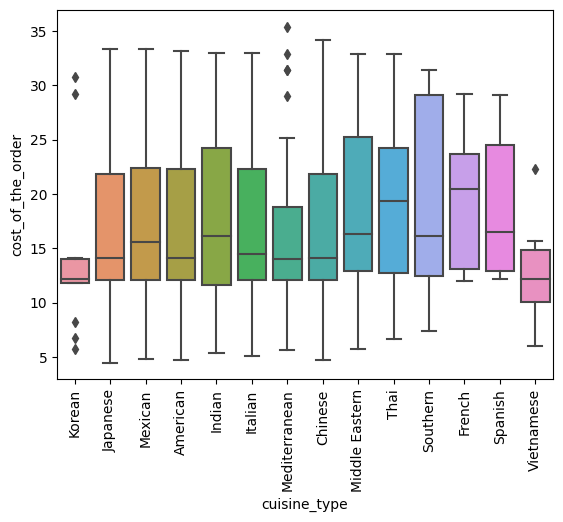

```python
# Realtionship between cuisine_type and cost_of_the_order
sns.boxplot( data = df , x = "cuisine_type", y = "cost_of_the_order")
plt.xticks(rotation = 90)
plt.show()
plt.title('Cuisine Type by Cost of the order')
```

The cost of the orders can be seen in relation to cuisine types.

[figure not shown]

```python
# Realtionship between cuisine_type and customer rating
plt.figure(figsize = (15,7))
sns.countplot(data = df, x = 'cuisine_type', hue = 'rating', order = df.cuisine_type.value_counts().iloc[0:10].index)
plt.title('Cuisine Type by Customer Ratings')
plt.show()
```

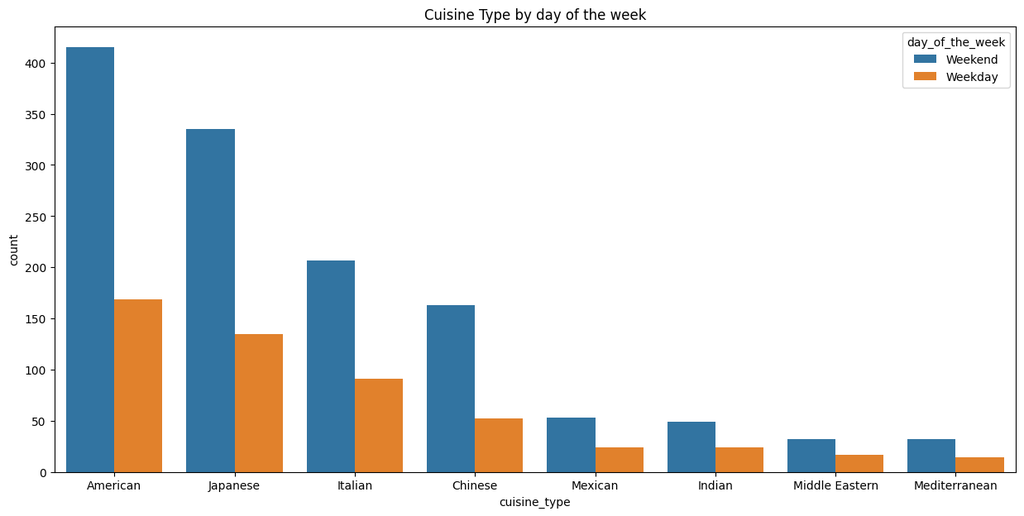

```python
# Realtionship between cuisine_type and day of the week
plt.figure(figsize = (15,7))
sns.countplot(data = df, x = 'cuisine_type', hue = 'day_of_the_week', order = df.cuisine_type.value_counts().iloc[:8].index)
plt.title('Cuisine Type by day of the week')
plt.show()
```

American, Japanese, Italian, and Chinese cuisine types remain the most popular throughout the entire week.

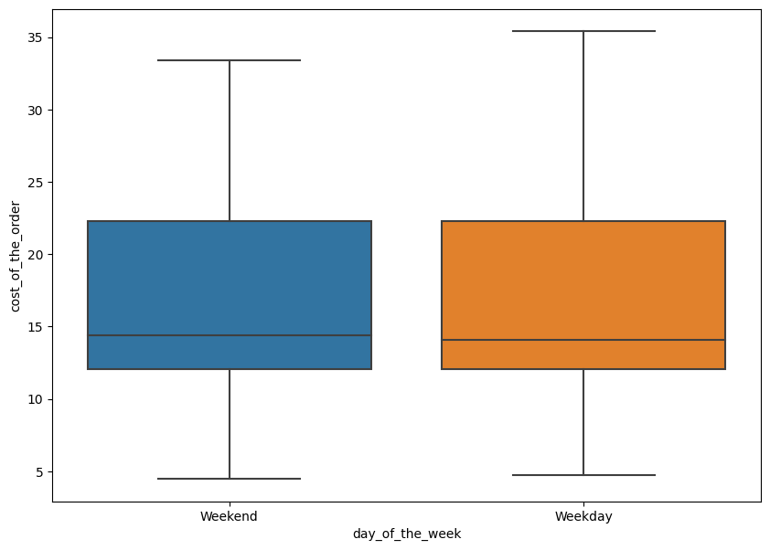

```python
# Relationship between day of the week and cost of the order
plt.figure(figsize=(10,7))
sns.boxplot(x = 'day_of_the_week', y = 'cost_of_the_order', data = df)
plt.title('Cost of the order by day of the week')
plt.show()
```

The mean order cost is slightly higher on the weekends.

[figure not shown]

```python
# Relationship between day of the week and delivery time
plt.figure(figsize=(10,7))
sns.barplot(data = df, x = 'day_of_the_week', y = 'delivery_time')
plt.title('Delivery time by day of the week')
plt.show()
```

On average delivery times are higher during the weekday than on the weekend.

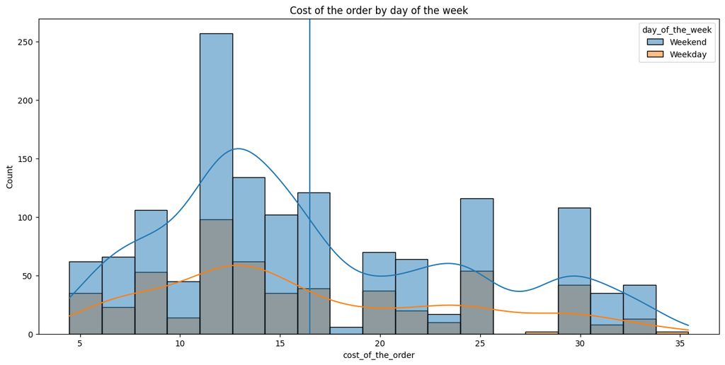

```python
# Relationship between day of the week and cost of the order
plt.figure(figsize = (15,7))
plt.axvline(df['cost_of_the_order'].mean())
sns.histplot(data = df, x = 'cost_of_the_order', hue = 'day_of_the_week', kde = True)
plt.title('Cost of the order by day of the week')
plt.show()
```

This histogram shows that more number of customers places orders on weekends rather than weekdays and customers order lower cost orders more than higher cost orders.

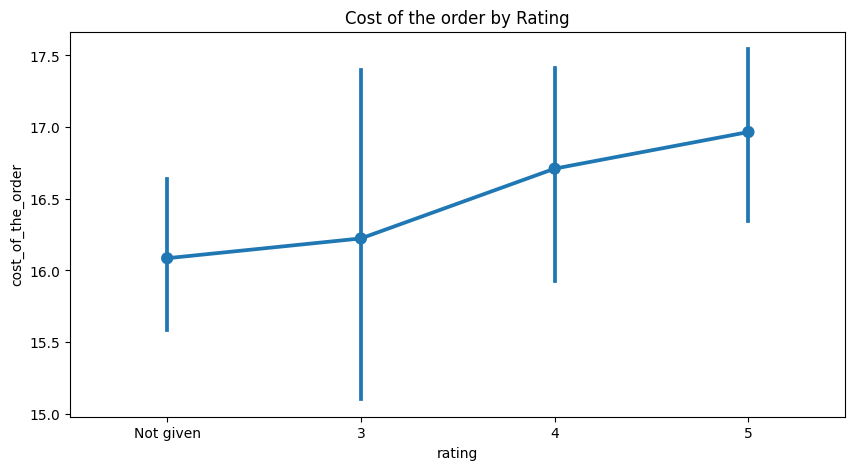

```python
# Relationship between rating and cost of the order
plt.figure(figsize=(10, 5))
sns.pointplot(x = 'rating', y = 'cost_of_the_order', order=['Not given', '3', '4', '5'], data = df)
plt.title('Cost of the order by Rating')
plt.show()
```

The ratings of 5 show there is a higher average cost of the order.

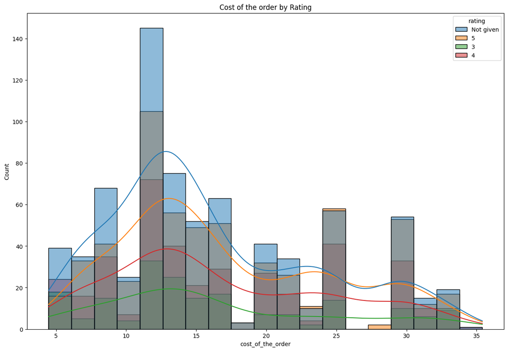

```python
# Relationship between rating and cost of the order
plt.figure(figsize = (15,10))
sns.histplot(data = df, x = 'cost_of_the_order', hue = 'rating', kde = True)
plt.title('Cost of the order by Rating')
plt.show()
```

Most customer order cost at about 11 and these customers have given the most ratings.

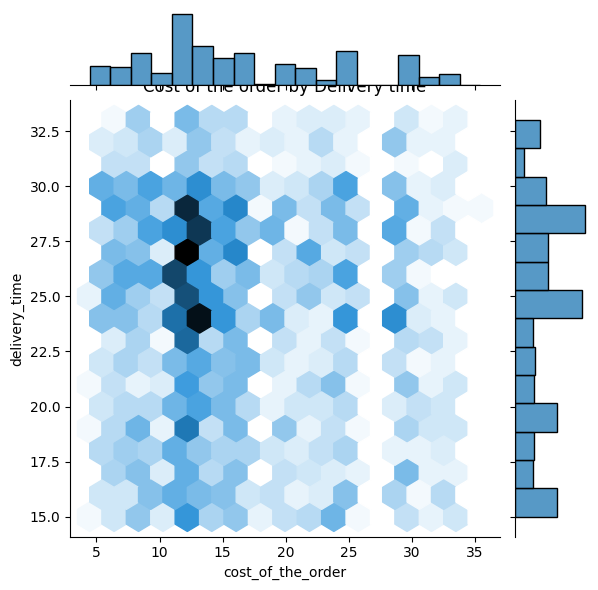

```python
# Relationship between delivery time and cost of the order
plt.figure(figsize = (15,10))
sns.jointplot(data = df, x = 'cost_of_the_order', y = 'delivery_time' , kind = 'hex')
plt.title('Cost of the order by Delivery time')
plt.show()
```

Cost_of_the_order is densely packed at about 11 and within a delivery_time of about 22.5 - 30 minutes.

### **Question 12:** The company wants to provide a promotional offer in the advertisement of the restaurants. The condition to get the offer is that the restaurants must have a rating count of more than 50 and the average rating should be greater than 4. Find the restaurants fulfilling the criteria to get the promotional offer. [3 marks]

```python
# Write the code here
# Group the data by restaurant_name to calculate rating-related statistics
# Filter the restaurants that meet the criteria
df1 = df[['restaurant_name','rating']][df['rating']!= 'Not given'].groupby('restaurant_name').mean()> 4
df1.reset_index(inplace=True)
df2 = df[['restaurant_name','rating']][df['rating']!= 'Not given'].groupby('restaurant_name').count()> 50
df2.reset_index(inplace=True)

promotional_restraunts = (pd.merge(df2[df2['rating']== True], df1[df1['rating']== True], on ='restaurant_name'))
promotional_restraunts = promotional_restraunts.drop(['rating_x', 'rating_y'] , axis = "columns")

# Print the restaurants fulfilling the criteria
print("Restaurants Fulfilling the Criteria for Promotional Offer:")
print(promotional_restraunts)
```

```
Restaurants Fulfilling the Criteria for Promotional Offer:
             restaurant_name
0  Blue Ribbon Fried Chicken
1          Blue Ribbon Sushi
2                Shake Shack
3          The Meatball Shop
```

#### Observations:

Only 4 restaurants meet the requirement for promotional offer in the advertisement of the restaurant.

1. The Meatball Shop
2. Blue Ribbon Fried Chicken
3. Shake Shack
4. Blue Ribbon Sushi

### **Question 13:** The company charges the restaurant 25% on the orders having cost greater than 20 dollars and 15% on the orders having cost greater than 5 dollars. Find the net revenue generated by the company across all orders. [2 marks]

```python
# Write the code here
sum = 0
for i in df['cost_of_the_order']:
    if (i > 20):
        sum = sum + (i*0.25)
    elif (5 < i < 20):
        sum = sum + (i*0.15)
    else:
        sum = sum + (i*0)
print('The net revenue on all orders is: {0}'.format(round(sum, 2)))
```

```
The net revenue on all orders is: 6166.3
```

#### Observations: The net revenue on all orders is **6166.30**.

### **Question 14:** The company wants to analyze the total time required to deliver the food. What percentage of orders take more than 60 minutes to get delivered from the time the order is placed? (The food has to be prepared and then delivered.) (Use .round function to round value to nearest zero) [2 marks]

```python
# Write the code here
# Calculate the total time required for each order (food preparation time + delivery time)
df['total_delivery_time'] = df['food_preparation_time'] + df['delivery_time']

# Calculate the percentage of orders that take more than 60 minutes
percentage_orders_over_60_minutes = (len(df[df['total_delivery_time'] > 60]) / len(df)) * 100

# Round the percentage to the nearest zero
rounded_percentage = round(percentage_orders_over_60_minutes, 0)

# Print the rounded percentage
print(f"Percentage of Orders Taking More Than 60 Minutes: {rounded_percentage}%")
```

```
Percentage of Orders Taking More Than 60 Minutes: 11.0%
```

#### Observations: Percentage of orders taking more than 60 minutes is **11%**

### **Question 15:** The company wants to analyze the delivery time of the orders on weekdays and weekends. How does the mean delivery time vary during weekdays and weekends? [2 marks]

```python
# Write the code here
df1 = df.groupby('day_of_the_week')['delivery_time'].mean()
df1
```

```
day_of_the_week
Weekday    28.340037
Weekend    22.470022
Name: delivery_time, dtype: float64
```

### Conclusion and Recommendations

### **Question 16:** What are your conclusions from the analysis? What recommendations would you like to share to help improve the business? (You can use cuisine type and feedback ratings to drive your business recommendations.) [4 marks]

### Conclusions:

- The majority of FoodHub orders were placed during the weekend. Out of all the orders placed the weekdays comprises of about 28.8% and weekends comprises of about 71.18%
- Out of 1200 customers , 784 have placed the order only once which is about 65.33% of our customers.
- Out of the 1898 orders 736 not rated which comprises of 38.7% of orders which are not rated.

### Recommendations:

- Increasing the cost_of_the_order on weekends will result in a significant higher net revenue and the number of delivery drivers should be increased on weekends due to higher order counts on weekends this will shorten the delivery time.
- Feedback should be taken for customers who have not ordered again. This will give us insights as to why a customer is not ordereing again.
- Ratings play a big role in getting feedback about our services and the areas to improve. Customers should be given a discount code if they rate on their next order. This will serve two purposes one is they will order a second time and we will also get the feedback.
- Feature the most popular cuisine type on weekends in advertisements to increase orders.
- Continue to use data analysis to make informed business decisions and adapt strategies to customer preferences and market trends.
- Strengthen partnerships with restaurants that meet the criteria for promotional offers, as these are likely to provide a positive customer experience.